# Profiling 2

mhv

12/19/2022

# Conclusion

- Version 1:
  - Store all function outputs directly in a big data frame.
- Version 2:
  - Store all function outputs in variables, then place them in the dataframe as a vector for each row.
- Version 3:
  - Like version 1, but without the inner loop. Instead the assignments of the elements in each row are hard coded.
  - This checks that the difference between version 1 and version 2 is not just caused by the extra loop in version 1.

Version 2 is very much faster than both version 1 and version 3: It is better to assign outputs to separate variables and then update each row in the data frame in one step, rather than place the outs of functions directly into the df.

See also /Users/mhvpbp13/Documents/Notes/Investering/rsystrade/Notes/rsystrade/Development/Coding paradigms - rsystrade.md

# Instructions:

Run everything at once.

# Performance test 2

```r
library("microbenchmark")
library("ggplot2")
library("magrittr")
```

## Setup

```r
#nrows <- 252 * 25 ## 6300 (25 years of trade data for single table)
nrows <- 252 ## One year of trade data
ncols <- 20
```

## Version 1

Store all function outputs directly in a big data frame.

```r
df <- data.frame(matrix(rep(0, nrows * ncols ), ncol = ncols))

version1 <- function(df) {
  for(i in 1:nrow(df)) {
    for(j in 1:ncol(df)) {
      df[i, j] <- j
    }
  }
  df
}

version1_out <- version1(df)
version1_out[1:2, ]
```

```
##   X1 X2 X3 X4 X5 X6 X7 X8 X9 X10 X11 X12 X13 X14 X15 X16 X17 X18 X19 X20
## 1  1  2  3  4  5  6  7  8  9  10  11  12  13  14  15  16  17  18  19  20
## 2  1  2  3  4  5  6  7  8  9  10  11  12  13  14  15  16  17  18  19  20
```

```r
rm(df)
```

## Version 2

Store all function outputs in variables, then place them in the dataframe as a vector for each row.

```r
df <- data.frame(matrix(rep(0, nrows * ncols ), ncol = ncols))

version2 <- function(df) {
  var1 <- 0
  var2 <- 0
  var3 <- 0
  var4 <- 0
  var5 <- 0
  var6 <- 0
  var7 <- 0
  var8 <- 0
  var9 <- 0
  var10 <- 0
  var11 <- 0
  var12 <- 0
  var13 <- 0
  var14 <- 0
  var15 <- 0
  var16 <- 0
  var17 <- 0
  var18 <- 0
  var19 <- 0
  var20 <- 0
  for(i in 1:nrow(df)) {
    var1 <- 1
    var2 <- 2
    var3 <- 3
    var4 <- 4
    var5 <- 5
    var6 <- 6
    var7 <- 7
    var8 <- 8
    var9 <- 9
    var10 <- 10
    var11 <- 11
    var12 <- 12
    var13 <- 13
    var14 <- 14
    var15 <- 15
    var16 <- 16
    var17 <- 17
    var18 <- 18
    var19 <- 19
    var20 <- 20
    df[i, ] <- c(
      var1,
      var2,
      var3,
      var4,
      var5,
      var6,
      var7,
      var8,
      var9,
      var10,
      var11,
      var12,
      var13,
      var14,
      var15,
      var16,
      var17,
      var18,
      var19,
      var20
    )
  }
  df
}

version2_out <- version2(df)
version2_out[1:2, ]
```

```
##   X1 X2 X3 X4 X5 X6 X7 X8 X9 X10 X11 X12 X13 X14 X15 X16 X17 X18 X19 X20
## 1  1  2  3  4  5  6  7  8  9  10  11  12  13  14  15  16  17  18  19  20
## 2  1  2  3  4  5  6  7  8  9  10  11  12  13  14  15  16  17  18  19  20
```

```r
rm(df)
```

## Version 3

Store all function outputs directly in a big data frame. Like version 1, but eliminate inner loop.

```r
df <- data.frame(matrix(rep(0, nrows * ncols ), ncol = ncols))

version3 <- function(df) {
  for(i in 1:nrow(df)) {
      df[i, 1] <- 1
      df[i, 2] <- 2
      df[i, 3] <- 3
      df[i, 4] <- 4
      df[i, 5] <- 5
      df[i, 6] <- 6
      df[i, 7] <- 7
      df[i, 8] <- 8
      df[i, 9] <- 9
      df[i, 10] <- 10
      df[i, 11] <- 11
      df[i, 12] <- 12
      df[i, 13] <- 13
      df[i, 14] <- 14
      df[i, 15] <- 15
      df[i, 16] <- 16
      df[i, 17] <- 17
      df[i, 18] <- 18
      df[i, 19] <- 19
      df[i, 20] <- 20
  }
  df
}

version3_out <- version3(df)
version3_out[1:2, ]
```

```
##   X1 X2 X3 X4 X5 X6 X7 X8 X9 X10 X11 X12 X13 X14 X15 X16 X17 X18 X19 X20
## 1  1  2  3  4  5  6  7  8  9  10  11  12  13  14  15  16  17  18  19  20
## 2  1  2  3  4  5  6  7  8  9  10  11  12  13  14  15  16  17  18  19  20
```

```r
rm(df)
```

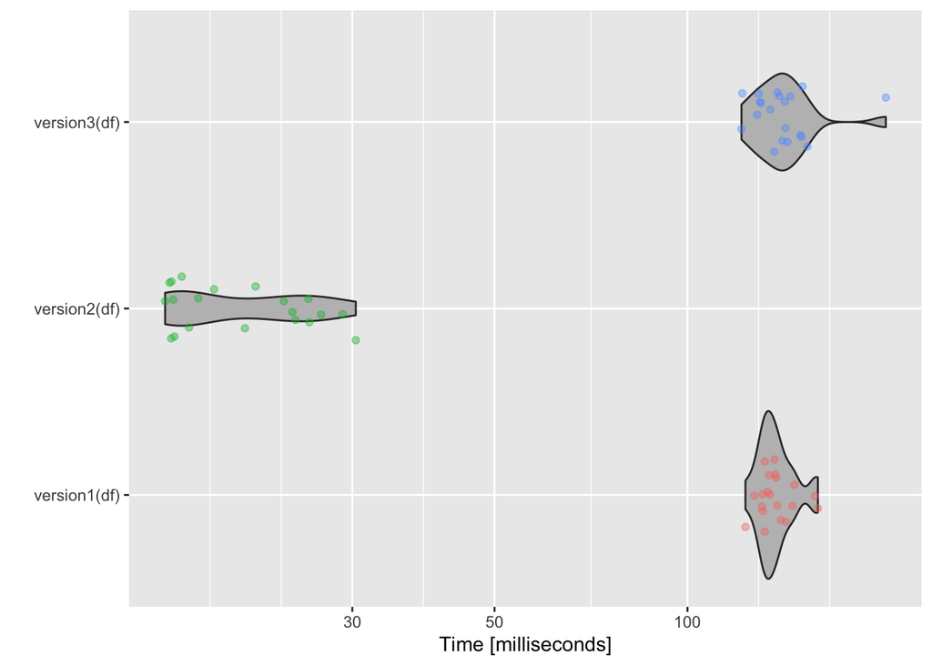

```r
df <- data.frame(matrix(rep(0, nrows * ncols ), ncol = ncols))

mb_out <- microbenchmark(
  version1(df),
  version2(df),
  version3(df),
  times = 20L
)

mb_plot <- autoplot(mb_out) +
  geom_jitter(position = position_jitter(0.2, 0),
              aes(color = expr), alpha = 0.4) +
  aes(fill = I("gray")) +
  theme(legend.position = "none")
mb_plot
```

```r
#labs(title = "", subtitle = "")

rm(df)
```

```r
summary(mb_out)
```

```
##           expr       min        lq     mean    median        uq       max neval
## 1 version1(df) 123.15604 131.54628 137.5644 135.56582 141.16658 159.77974    20
## 2 version2(df)  15.31137  15.80392  20.6699  19.32397  25.03262  30.37346    20
## 3 version3(df) 121.41300 129.99712 141.5755 139.90904 147.37138 203.94295    20
```

Run benchmark test again

```r
df <- data.frame(matrix(rep(0, nrows * ncols ), ncol = ncols))

mb_out <- microbenchmark(
  version1(df),
  version2(df),
  version3(df),
  times = 20L
)
summary(mb_out)
```

```
##           expr       min        lq      mean    median        uq       max
## 1 version1(df) 126.88074 134.00784 152.07390 142.29014 158.28877 222.44145
## 2 version2(df)  16.19254  18.36369  27.00071  21.35146  31.97566  80.14638
## 3 version3(df) 118.79710 131.28413 171.95730 152.59323 191.39781 286.16327
##   neval
## 1    20
## 2    20
## 3    20
```

```r
rm(df)
```